```python
import numpy as np
import scipy
import matplotlib.pyplot as plt
import seaborn as sns

import sys
```

# 100 задач с numpy

Курс "Модели и методы интеллектуального анализа данных"

Чернышов Юрий

к.ф.-м.н., доцент кафедры ИТЗИ УрГУПС (Екатеринбург)

yuchernyshov@usurt.ru

# Оглавление

1. Введение
2. 10 простых примеров использования библиотеки numpy
3. Основы работы с numpy
4. Получение информации об объектах numpy.
5. Доступ к объектам numpy.
6. Операции над объектами numpy
7. Настройки системы
8. Ссылки

# Введение

Библиотека numpy содержит множество стандартных математических функций, в том числе широкий набор инструментов для использования при обработке данных. Важным преимуществом numpy является значительная оптимизация выполнения задач обработки больших массивов за счет специальной реализации функций. Скорость может увеличиваться на порядки. Основные используемые при этом операции - векторизация и укладка, которые дают выигрыш по сравнению с использованием обычных циклов и рекомендуются для реализации алгоритмов (в том числе алгоритмов машинного обучения).

Документ содержит практические примеры работы с библиотекой numpy. Материал состоит из 100 типовых задач, которые можно сделать в numpy.

Для начала практического изучения использования библиотеки numpy рекомендуется рассмотреть раздел "10 простых примеров использования numpy" (этого зачастую достаточно для решения большинства задач), после чего переходить к более сложным примерам. При невозможности установки python и numpy для практической работы можно воспользоваться ресурсом "Google colab" https://colab.research.google.com/

Подробные описания использованных функций находятся на официальной странице проекта https://numpy.org/

Для удобства задачи разбиты на группы, к которым удобно переходить через Оглавление.

Назад к Оглавлению

# 10 простых примеров использования библиотеки numpy

#### Загрузить библиотеку numpy

```python
import numpy as np
print(np.__version__)
```

```
1.16.2
```

#### Моздать массив numpy

```python
m = np.array([1,2,3])
print(m)
print(type(m))
```

```
[1 2 3]
<class 'numpy.ndarray'>
```

#### Создать массив numpy из чисел определенного диапазона

Указывается шаг

```python
np.arange(-10, 10, 2)
```

```
array([-10,  -8,  -6,  -4,  -2,   0,   2,   4,   6,   8])
```

Указывается количество точек

```python
np.linspace(-1, 1, 20)
```

```
array([-1.        , -0.89473684, -0.78947368, -0.68421053, -0.57894737,
       -0.47368421, -0.36842105, -0.26315789, -0.15789474, -0.05263158,
        0.05263158,  0.15789474,  0.26315789,  0.36842105,  0.47368421,
        0.57894737,  0.68421053,  0.78947368,  0.89473684,  1.        ])
```

#### Создать двумерный массив numpy

```python
m = np.array([[1,2], [3,4]])
print(m)
print(m[1,1])
```

```
[[1 2]
 [3 4]]
4
```

#### Изменить размеры массива numpy

```python
m = np.arange(1, 10).reshape(3, 3)
m
```

```
array([[1, 2, 3],
       [4, 5, 6],
       [7, 8, 9]])
```

```python
print(m[1, 1])
print(m.shape)
```

```
5
(3, 3)
```

#### Найти максимальный и минимальный элементы массива

```python
m = np.array([1, 3, 2, 4, 5, -1])
print(m)
print(np.max(m))
print(np.min(m))
```

```
[ 1  3  2  4  5 -1]
5
-1
```

#### Операции сложения, вычитания, умножения на число для массивов

```python
a = np.array([1,2,3])
b = np.array([1,2,3])

print(a+b)
print(a-b)
print(3*a)
```

```
[2 4 6]
[0 0 0]
[3 6 9]
```

#### Вычислить скалярное произведение двух массивов

```python
a = np.array([1,2,3])
b = np.array([1,2,3])
np.dot(a, b)
```

```
14
```

#### Создать массив из случайных значений

```python
np.random.random(5)
```

```
array([0.16409369, 0.0250881 , 0.30741042, 0.46695773, 0.71975171])
```

#### Вычислить среднее значение и дисперсию

```python
m = np.random.random(10)
print(np.mean(m))
print(np.var(m))
```

```
0.5329533462968976
0.06778055708852763
```

Назад к Оглавлению

Назад к Оглавлению

# Основы работы с numpy

#### Получить документацию для функции numpy (например, numpy.sum)

```python
np.info(np.sum)
```

```
 sum(a, axis=None, dtype=None, out=None, keepdims=<no value>,
     initial=<no value>)

Sum of array elements over a given axis.

Parameters
----------
a : array_like
    Elements to sum.
axis : None or int or tuple of ints, optional
    Axis or axes along which a sum is performed.  The default,
    axis=None, will sum all of the elements of the input array.  If
    axis is negative it counts from the last to the first axis.

    .. versionadded:: 1.7.0

    If axis is a tuple of ints, a sum is performed on all of the axes
    specified in the tuple instead of a single axis or all the axes as
    before.
dtype : dtype, optional
    The type of the returned array and of the accumulator in which the
    elements are summed.  The dtype of `a` is used by default unless `a`
    has an integer dtype of less precision than the default platform
    integer.  In that case, if `a` is signed then the platform integer
    is used while if `a` is unsigned then an unsigned integer of the
    same precision as the platform integer is used.
out : ndarray, optional
    Alternative output array in which to place the result. It must have
    the same shape as the expected output, but the type of the output
    values will be cast if necessary.
keepdims : bool, optional
    If this is set to True, the axes which are reduced are left
    in the result as dimensions with size one. With this option,
    the result will broadcast correctly against the input array.

    If the default value is passed, then `keepdims` will not be
    passed through to the `sum` method of sub-classes of
    `ndarray`, however any non-default value will be.  If the
    sub-class' method does not implement `keepdims` any
    exceptions will be raised.
```

[output cut: 40 more lines]

```
6
>>> np.sum([[0, 1], [0, 5]], axis=0)
array([0, 6])
>>> np.sum([[0, 1], [0, 5]], axis=1)
array([1, 5])

If the accumulator is too small, overflow occurs:

>>> np.ones(128, dtype=np.int8).sum(dtype=np.int8)
-128

You can also start the sum with a value other than zero:

>>> np.sum([10], initial=5)
15
```

#### Встроенные константы $\pi$ и $e$.

```python
np.pi, np.e
```

```
(3.141592653589793, 2.718281828459045)
```

#### Встроенные элементарные функции.

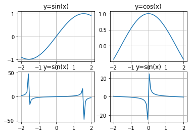

```python
plt.figure(figsize=(10,7))
xs = np.linspace(-2, 2, 50)
fig, ax = plt.subplots(2, 2)
ax[0][0].plot(xs, np.sin(xs)); ax[0][0].set_title("y=sin(x)"); ax[0][0].grid(True)
ax[0][1].plot(xs, np.cos(xs)); ax[0][1].set_title("y=cos(x)"); ax[0][1].grid(True)
ax[1][0].plot(xs, np.tan(xs)); ax[1][0].set_title("y=sin(x)"); ax[1][0].grid(True)
ax[1][1].plot(xs, 1/np.tan(xs)); ax[1][1].set_title("y=sin(x)"); ax[1][1].grid(True)
plt.show()
```

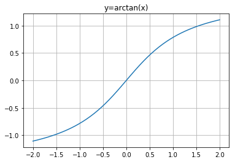

```python
plt.plot(xs, np.arctan(xs)); plt.grid(True); plt.title("y=arctan(x)"); plt.show()
```

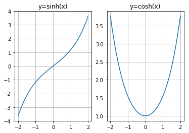

```python
fig, ax = plt.subplots(1,2)
ax[0].plot(xs, np.sinh(xs)); ax[0].grid(True); ax[0].set_title('y=sinh(x)')
ax[1].plot(xs, np.cosh(xs)); ax[1].grid(True); ax[1].set_title('y=cosh(x)')
plt.show()
```

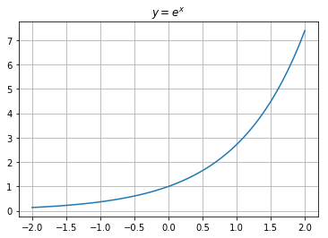

```python
plt.plot(xs, np.exp(xs)); plt.grid(True); plt.title("$y=e^x$"); plt.show()
```

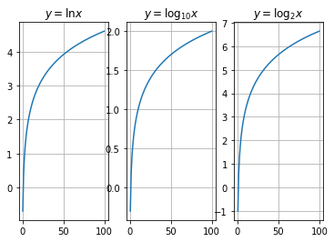

```python
xs1 = np.linspace(0.5, 100, 100)
fig, ax = plt.subplots(1,3)
ax[0].plot(xs1, np.log(xs1)); ax[0].grid(True); ax[0].set_title("$y=\ln x$")
ax[1].plot(xs1, np.log10(xs1)); ax[1].grid(True); ax[1].set_title("$y=\log_{10} x$")
ax[2].plot(xs1, np.log2(xs1)); ax[2].grid(True); ax[2].set_title("$y=\log_{2} x$")
plt.show()
```

#### Выражения np.nan, np.inf

```python
print(0 * np.nan)
print(np.nan == np.nan)
print(np.inf > np.nan)
print(np.nan - np.nan)
```

```
nan
False
False
nan
```

#### Демонстрация эффекта использования numpy по сравнению с обычными объектами

```python
import time

a = np.random.rand(1000000)
b = np.random.rand(1000000)

tic = time.time()
c = np.dot(a, b)
toc = time.time()
print("np.dot works {} ms, result: {}".format(1000*(toc-tic), c))

c = 0
tic = time.time()
for i in range(1000000):
    c += a[i]*b[i]
toc = time.time()
print("for loop works {} ms, result: {}".format(1000*(toc-tic), c))
```

```
np.dot works 1.0907649993896484 ms, result: 249825.20911152728
for loop works 255.10358810424805 ms, result: 249825.20911152728
```

Назад к Оглавлению

# Создание объектов numpy

```python
a = np.array([1,2,3])
```

```python
a.sum(), a.min()
```

```
(6, 1)
```

#### Создать вектор (одномерный массив) размера 10, заполненный нулями

```python
np.zeros(10)
```

```
array([0., 0., 0., 0., 0., 0., 0., 0., 0., 0.])
```

#### Создать вектор размера 11, заполненный единицами

```python
np.ones(11)
```

```
array([1., 1., 1., 1., 1., 1., 1., 1., 1., 1., 1.])
```

#### Создать вектор размера 12, заполненный числом $\pi$

```python
np.full(12, np.pi)
```

```
array([3.14159265, 3.14159265, 3.14159265, 3.14159265, 3.14159265,
       3.14159265, 3.14159265, 3.14159265, 3.14159265, 3.14159265,
       3.14159265, 3.14159265])
```

#### Создать вектор размера 5, заполненный нулями, но третий элемент равен 2.7

```python
arr = np.zeros(5)
arr[2] = 2.7
print(arr)
```

```
[0.  0.  2.7 0.  0. ]
```

#### Создать вектор со значениями от 10 до 50

```python
np.arange(10, 51)
```

```
array([10, 11, 12, 13, 14, 15, 16, 17, 18, 19, 20, 21, 22, 23, 24, 25, 26,
       27, 28, 29, 30, 31, 32, 33, 34, 35, 36, 37, 38, 39, 40, 41, 42, 43,
       44, 45, 46, 47, 48, 49, 50])
```

#### Создать вектор из квадратов первых 10 натуральных чисел и развернуть этот вектор (первый становится последним).

```python
arr = np.arange(1, 11)
arr = arr**2
arr = arr[::-1]
print(arr)
```

```
[100  81  64  49  36  25  16   9   4   1]
```

Это же действие можно выполнить в одну строку

```python
(np.arange(1, 11)**2)[::-1]
```

```
array([100,  81,  64,  49,  36,  25,  16,   9,   4,   1])
```

#### Создать матрицу (двумерный массив) 3x3 со значениями от 10 до 90

Создаем одномерный массив из девяти элементов и меняем его размерность на 3х3.

```python
np.arange(10, 100, 10).reshape(3,3)
```

```
array([[10, 20, 30],
       [40, 50, 60],
       [70, 80, 90]])
```

#### Создать 3x3 единичную матрицу

```python
np.eye(3)
```

```
array([[1., 0., 0.],
       [0., 1., 0.],
       [0., 0., 1.]])
```

#### Создать массив 3x3x3 со случайными значениями от 0 до 1

```python
arr = np.random.random((3, 3, 3))
print(arr)
print(arr[1][1][1])
```

```
[[[0.7742905  0.78442811 0.63927865]
  [0.23362844 0.93856854 0.21881081]
  [0.09898633 0.47542195 0.06553681]]

 [[0.01430701 0.45687428 0.66534132]
  [0.23886616 0.57385507 0.45523122]
  [0.35364163 0.31756203 0.39456868]]

 [[0.08130147 0.48518865 0.28951884]
  [0.91598521 0.86865169 0.35525648]
  [0.44927346 0.54230895 0.69712553]]]
0.5738550675952979
```

#### Создать матрицу с 1 внутри, и 0 на границах

```python
matrix = np.zeros((5, 5))
matrix[1:-1, 1:-1] = 1
print(matrix)
```

```
[[0. 0. 0. 0. 0.]
 [0. 1. 1. 1. 0.]
 [0. 1. 1. 1. 0.]
 [0. 1. 1. 1. 0.]
 [0. 0. 0. 0. 0.]]
```

#### Создать 5x5 матрицу с 1,2,3,4 под диагональю (остальные элементы - нули).

```python
matrix = np.diag(np.arange(1, 5), k=-1)
print(matrix)
```

```
[[0 0 0 0 0]
 [1 0 0 0 0]
 [0 2 0 0 0]
 [0 0 3 0 0]
 [0 0 0 4 0]]
```

#### Создать 8x8 матрицу и заполнить её в шахматном порядке нулями и единицами.

```python
m = np.zeros((8, 8))
m[1::2, ::2] = 1
m[::2, 1::2] = 1
print(m)
```

```
[[0. 1. 0. 1. 0. 1. 0. 1.]
 [1. 0. 1. 0. 1. 0. 1. 0.]
 [0. 1. 0. 1. 0. 1. 0. 1.]
 [1. 0. 1. 0. 1. 0. 1. 0.]
 [0. 1. 0. 1. 0. 1. 0. 1.]
 [1. 0. 1. 0. 1. 0. 1. 0.]
 [0. 1. 0. 1. 0. 1. 0. 1.]
 [1. 0. 1. 0. 1. 0. 1. 0.]]
```

#### Создать 8x8 матрицу и заполнить её в шахматном порядке, используя функцию tile

```python
arr = np.tile([[0,1], [1,0]], (4, 4))
print(arr)
```

```
[[0 1 0 1 0 1 0 1]
 [1 0 1 0 1 0 1 0]
 [0 1 0 1 0 1 0 1]
 [1 0 1 0 1 0 1 0]
 [0 1 0 1 0 1 0 1]
 [1 0 1 0 1 0 1 0]
 [0 1 0 1 0 1 0 1]
 [1 0 1 0 1 0 1 0]]
```

#### Окружить заданный массив строчками и столбцами из нулей

```python
a = np.random.random(24).reshape(-1, 4)
print(a, "\n", a.shape, "\n")
a = np.hstack((np.zeros(a.shape[0]).reshape(-1,1), a))
a = np.hstack((a, np.zeros(a.shape[0]).reshape(-1,1)))
a = np.vstack((np.zeros(a.shape[1]), a))
a = np.vstack((a, np.zeros(a.shape[1])))
print(a)
```

```
[[0.96064732 0.64895473 0.40458101 0.05834649]
 [0.83092138 0.50232315 0.14790539 0.3520593 ]
 [0.00527749 0.65995833 0.16763544 0.01592309]
 [0.37499648 0.34054369 0.93451814 0.54927778]
 [0.23639349 0.17636388 0.63867023 0.64336251]
 [0.65591327 0.38953228 0.76974528 0.60981378]]
 (6, 4)

[[0.         0.         0.         0.         0.         0.        ]
 [0.         0.96064732 0.64895473 0.40458101 0.05834649 0.        ]
 [0.         0.83092138 0.50232315 0.14790539 0.3520593  0.        ]
 [0.         0.00527749 0.65995833 0.16763544 0.01592309 0.        ]
 [0.         0.37499648 0.34054369 0.93451814 0.54927778 0.        ]
 [0.         0.23639349 0.17636388 0.63867023 0.64336251 0.        ]
 [0.         0.65591327 0.38953228 0.76974528 0.60981378 0.        ]
 [0.         0.         0.         0.         0.         0.        ]]
```

#### Создать массив 10х10, заполнив его значениями заданной функции

```python
def f(x, y):
    return 100*x+y
np.fromfunction(f, (10,10), dtype=int)
```

```
array([[  0,   1,   2,   3,   4,   5,   6,   7,   8,   9],
       [100, 101, 102, 103, 104, 105, 106, 107, 108, 109],
       [200, 201, 202, 203, 204, 205, 206, 207, 208, 209],
       [300, 301, 302, 303, 304, 305, 306, 307, 308, 309],
       [400, 401, 402, 403, 404, 405, 406, 407, 408, 409],
       [500, 501, 502, 503, 504, 505, 506, 507, 508, 509],
       [600, 601, 602, 603, 604, 605, 606, 607, 608, 609],
       [700, 701, 702, 703, 704, 705, 706, 707, 708, 709],
       [800, 801, 802, 803, 804, 805, 806, 807, 808, 809],
       [900, 901, 902, 903, 904, 905, 906, 907, 908, 909]])
```

#### Создание разреженной матрицы

```python
a = np.array([[0 if (i+j)%10 else i*j for i in range(10)] for j in range(10)])
print(a)
sparse_matrix = scipy.sparse.csr_matrix(a)
print(sparse_matrix)
```

```
[[ 0  0  0  0  0  0  0  0  0  0]
 [ 0  0  0  0  0  0  0  0  0  9]
 [ 0  0  0  0  0  0  0  0 16  0]
 [ 0  0  0  0  0  0  0 21  0  0]
 [ 0  0  0  0  0  0 24  0  0  0]
 [ 0  0  0  0  0 25  0  0  0  0]
 [ 0  0  0  0 24  0  0  0  0  0]
 [ 0  0  0 21  0  0  0  0  0  0]
 [ 0  0 16  0  0  0  0  0  0  0]
 [ 0  9  0  0  0  0  0  0  0  0]]
  (1, 9)	9
  (2, 8)	16
  (3, 7)	21
  (4, 6)	24
  (5, 5)	25
  (6, 4)	24
  (7, 3)	21
  (8, 2)	16
  (9, 1)	9
```

Пример преимущества использования разреженных матриц для экономии памяти и увеличения скорости выполнения операций.

```python
m1 = np.array([[1 if v<0.0001 else 0 for v in np.random.random(1000)] for j in range(1000)])
m2 = np.array([[1 if v<0.0001 else 0 for v in np.random.random(1000)] for j in range(1000)])

np.bincount(m1.flatten()), np.bincount(m2.flatten())
```

```
(array([999890,    110]), array([999883,    117]))
```

```python
%%time
print(sys.getsizeof(m1))
print(sys.getsizeof(m2))
np.dot(m1, m2)
```

```
8000112
8000112
CPU times: user 853 ms, sys: 0 ns, total: 853 ms
Wall time: 851 ms
```

```
array([[0, 0, 0, ..., 0, 0, 0],
       [0, 0, 0, ..., 0, 0, 0],
       [0, 0, 0, ..., 0, 0, 0],
       ...,
       [0, 0, 0, ..., 0, 0, 0],
       [0, 0, 0, ..., 0, 0, 0],
       [0, 0, 0, ..., 0, 0, 0]])
```

```python
sm1 = scipy.sparse.csr_matrix(m1)
sm2 = scipy.sparse.csr_matrix(m2)
```

```python
%%time
print(sys.getsizeof(sm1))
print(sys.getsizeof(sm2))
np.dot(sm1, sm2)
```

```
64
64
CPU times: user 755 µs, sys: 97 µs, total: 852 µs
Wall time: 485 µs
```

```
<1000x1000 sparse matrix of type '<class 'numpy.int64'>'
	with 17 stored elements in Compressed Sparse Row format>
```

#### Создать нормально распределенную случайную величину с заданным средним значением

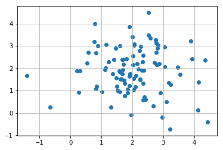

```python
a = np.random.normal(size=(100, 2), loc=2)
plt.scatter(a.ravel()[::2], a.ravel()[1::2])
plt.grid(True)
plt.show()
```

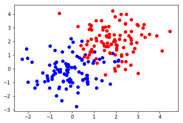

```python
data1 = np.random.normal(size=(100, 2), loc=0)
data2 = np.random.normal(size=(100, 2), loc=2)
plt.scatter(data1[:,0], data1[:,1], c='b')
plt.scatter(data2[:,0], data2[:,1], c='r')
plt.show()
```

#### Создать равномерно распределенную случайную величину

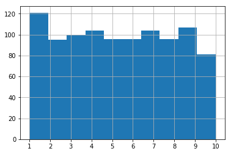

```python
a = np.random.uniform(1, 10, 1000)
plt.xticks(range(1, 11))
plt.grid(True)
plt.hist(a)
plt.show()
```

#### Создать массив значений по логарифмической шкале.

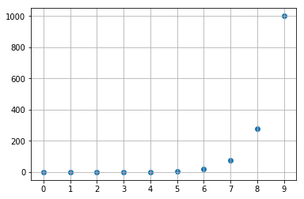

```python
plt.scatter(range(10), np.logspace(-2, 3, 10))
plt.xticks(range(10))
plt.grid(True)
plt.show()
```

#### Создать равномерный массив чисел

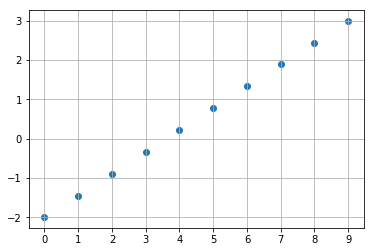

```python
plt.scatter(range(10), np.linspace(-2, 3, 10))
plt.xticks(range(10))
plt.grid(True)
plt.show()
```

#### Создать массив-сетку

```python
xx, yy = np.meshgrid(np.arange(-1.5, 1.5, 0.01), np.arange(-1.5, 1.5, 0.01))
```

```python
xx.shape, yy.shape
```

```
((300, 300), (300, 300))
```

Отобразим точки, лежащие внутри единичной окружности, желтым цветом, а вне ее - красным.

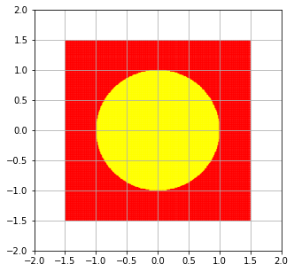

```python
plt.figure(figsize=(5,5))
plt.xlim(-2,2)
plt.ylim(-2,2)
color = np.array([1 if x**2+y**2<1 else 0 for x, y in zip(xx.ravel(), yy.ravel())])
plt.pcolormesh(xx, yy, color.reshape(xx.shape), alpha=0.5, cmap='autumn')
plt.grid(True)
plt.show()
```

Перейти к Оглавлению

# Получение информации об объектах numpy.

#### Узнать размер массива

```python
a = np.random.random(10)
print(a)
print("Размер массива, nbytes: ", a.nbytes)
print("Размер массива, sys.getsizeof: ", sys.getsizeof(a))
```

```
[0.66795731 0.51887584 0.30896314 0.64969946 0.57522344 0.76534607
 0.82951732 0.19414857 0.07324248 0.80438272]
Размер массива, nbytes:  80
Размер массива, sys.getsizeof:  176
```

#### Найти размеры в массивах большой размерности

```python
A = np.array([[[i+j+k for i in range(3)] for j in range(4)] for k in range(5)])
print(A)
```

```
[[[0 1 2]
  [1 2 3]
  [2 3 4]
  [3 4 5]]

 [[1 2 3]
  [2 3 4]
  [3 4 5]
  [4 5 6]]

 [[2 3 4]
  [3 4 5]
  [4 5 6]
  [5 6 7]]

 [[3 4 5]
  [4 5 6]
  [5 6 7]
  [6 7 8]]

 [[4 5 6]
  [5 6 7]
  [6 7 8]
  [7 8 9]]]
```

```python
print("Размеры массива: {}, количество элементов: {}, количество измерений: {}".format(A.shape, A.size, A.ndim))
```

```
Размеры массива: (5, 4, 3), количество элементов: 60, количество измерений: 3
```

#### Создать массив 10x10 со случайными значениями, найти минимум, максимум, математическое ожидание, дисперсию

```python
arr = np.random.random((10, 10))
for row in arr:
    print("  ".join(["{:.2f}".format(i) for i in row]))
print("Размеры матрицы: ", arr.shape)
print("Минимум: ", arr.min())
print("Максимум: ", arr.max())
print("Среднее арифметическое: ", arr.mean(), np.sum(arr)/arr.shape[0]/arr.shape[1])
print("Дисперсия: ", arr.var(), np.sum((arr - arr.mean())**2)/(arr.shape[0] * arr.shape[1]))
print("Отклонение: ", arr.std())
```

```
0.53  0.63  0.86  0.90  0.30  0.42  0.89  0.35  0.67  0.38
0.03  0.58  0.79  0.17  0.03  0.61  0.38  0.67  0.85  0.01
0.75  0.67  0.91  0.54  0.46  0.84  0.74  0.92  0.36  0.52
0.49  0.67  0.95  0.03  0.96  0.31  0.57  0.26  0.14  0.67
0.57  0.38  0.25  0.78  0.48  0.43  0.45  0.01  0.03  0.92
0.99  0.46  0.21  0.17  0.65  0.48  0.23  0.90  0.99  0.24
0.69  0.78  0.84  0.87  0.66  0.51  0.96  0.54  0.26  0.50
0.01  0.71  0.94  0.51  0.28  0.39  0.33  0.60  0.41  0.66
0.00  0.33  0.22  0.44  0.91  0.40  0.88  0.46  0.92  0.79
0.38  0.90  0.01  0.46  0.57  0.97  0.60  0.45  0.16  0.53
Размеры матрицы:  (10, 10)
Минимум:  0.004951390781267384
Максимум:  0.994117561168992
Среднее арифметическое:  0.5329546452910808 0.5329546452910809
Дисперсия:  0.0786974400747261 0.0786974400747261
Отклонение:  0.28053064017095547
```

```python
arr.max(axis=1)
```

```
array([0.89842598, 0.8518032 , 0.91569481, 0.95910669, 0.91536901,
       0.99411756, 0.95870547, 0.93840125, 0.92050158, 0.97044284])
```

```python
arr.max(axis=0)
```

```
array([0.99411756, 0.89532546, 0.95142251, 0.89842598, 0.95910669,
       0.97044284, 0.95870547, 0.91569481, 0.99173855, 0.91536901])
```

#### Найти среднее значение для каждого столбца

```python
arr.mean(axis=0)
```

```
array([0.44461048, 0.61072297, 0.59846   , 0.48794636, 0.52955521,
       0.53750286, 0.60336641, 0.51476368, 0.48051341, 0.52210508])
```

```python
np.average(arr, axis=0)
```

```
array([0.44461048, 0.61072297, 0.59846   , 0.48794636, 0.52955521,
       0.53750286, 0.60336641, 0.51476368, 0.48051341, 0.52210508])
```

#### Дан массив размерности (6,7,8). Каков индекс (x,y,z) сотого элемента?

```python
np.unravel_index(100, (6, 7, 8))
```

```
(1, 5, 4)
```

#### Найти индексы ненулевых элементов в [1,2,0,0,4,0]

```python
indexes = np.nonzero([1,2,0,0,4,0])
print(indexes)
```

```
(array([0, 1, 4]),)
```

#### Найти количество вхождений элементов

```python
a = np.random.choice([0,1,2], 20)
print(a)
np.bincount(a)
```

```
[2 1 2 2 0 2 2 0 1 0 2 0 0 0 2 2 0 0 0 1]
```

```
array([9, 3, 8])
```

Назад к Оглавлению

# Доступ к элементам объекта numpy

#### Изменение размерности массива

```python
A = np.arange(12)
print(A)
```

```
[ 0  1  2  3  4  5  6  7  8  9 10 11]
```

```python
A.reshape(4,-1)
```

```
array([[ 0,  1,  2],
       [ 3,  4,  5],
       [ 6,  7,  8],
       [ 9, 10, 11]])
```

```python
A.flatten()
```

```
array([ 0,  1,  2,  3,  4,  5,  6,  7,  8,  9, 10, 11])
```

#### Выбрать только четные элементы массива

```python
a = np.arange(10)
print(a)
```

```
[0 1 2 3 4 5 6 7 8 9]
```

```python
a%2==0
```

```
array([ True, False,  True, False,  True, False,  True, False,  True,
       False])
```

```python
a[a%2==0]
```

```
array([0, 2, 4, 6, 8])
```

```python
np.where(a%2==0)
```

```
(array([0, 2, 4, 6, 8]),)
```

#### В массиве из двух столбцов выбрать значения второго столбца, наложив условия на первый столбец

```python
a = np.random.randint(1, 10, 16).reshape(-1,2)
y = np.random.choice([0, 1], 8)
```

```python
a, y
```

```
(array([[1, 1],
        [3, 7],
        [6, 9],
        [1, 2],
        [8, 8],
        [5, 5],
        [6, 9],
        [1, 9]]),
 array([1, 0, 1, 1, 0, 0, 1, 0]))
```

```python
y==1
```

```
array([ True, False,  True,  True, False, False,  True, False])
```

```python
a[y==1, 1]
```

```
array([1, 9, 2, 9])
```

Назад к Оглавлению

# Операции над объектами numpy

#### Умножить все элементы массива на число

```python
%%time
a = np.random.randint(1, 100, 1000000)
a1 = a*2
a1
```

```
CPU times: user 8.7 ms, sys: 70 µs, total: 8.77 ms
Wall time: 8.56 ms
```

```
array([128, 154, 142, ...,  64,  34, 174])
```

#### Сложение, вычитание массивов, умножение на число, возведение в степень, вычисление функции от элементов массива

```python
a = np.arange(5)
b = np.array([10,20,30,40,50])
print(b+a)
print(b-a)
print(a*5)
print(a**3)
print(np.sin(a))
```

```
[10 21 32 43 54]
[10 19 28 37 46]
[ 0  5 10 15 20]
[ 0  1  8 27 64]
[ 0.          0.84147098  0.90929743  0.14112001 -0.7568025 ]
```

#### Объединение массивов

```python
a = np.array([i for i in range(5)])
b = np.ones(5)
print(a, b)
```

```
[0 1 2 3 4] [1. 1. 1. 1. 1.]
```

Объединить массивы как строки, в одной строке

```python
np.r_[a,b]
```

```
array([0., 1., 2., 3., 4., 1., 1., 1., 1., 1.])
```

Объединить массивы как столбцы.

```python
np.c_[a,b]
```

```
array([[0., 1.],
       [1., 1.],
       [2., 1.],
       [3., 1.],
       [4., 1.]])
```

```python
np.r_[-1:1:6j, [0]*3, 5, 6]
```

```
array([-1. , -0.6, -0.2,  0.2,  0.6,  1. ,  0. ,  0. ,  0. ,  5. ,  6. ])
```

#### Вертикальная и горизонтальная склейка массивов

```python
a = np.arange(4).reshape(2,2)
b = np.arange(4).reshape(2,2)
print(a)
print("")
print(b)
print("Вертикальная склейка:")
print(np.vstack((a,b)))
print("Горизонтальная склейка:")
print(np.hstack((a,b)))
```

```
[[0 1]
 [2 3]]

[[0 1]
 [2 3]]
Вертикальная склейка:
[[0 1]
 [2 3]
 [0 1]
 [2 3]]
Горизонтальная склейка:
[[0 1 0 1]
 [2 3 2 3]]
```

#### В массиве numpy выделить элементы по признаку

```python
a = np.array([np.random.choice([1,2,3]) for _ in range(5)])
print(a)
print(np.where(a==2))
```

```
[3 1 3 1 2]
(array([4]),)
```

```python
print(np.isin(a, [1,2]))
print(a[np.isin(a, [1,2])])
```

```
[False  True False  True  True]
[1 1 2]
```

#### Найти перцентиль

```python
a = np.random.uniform(1, 100, 50)
np.percentile(a, 95)
```

```
97.66890595393531
```

```
3.469394608953486 98.85365822032902
[2.93496743 3.10506991]
[99.65833653 98.9689292 ]
```

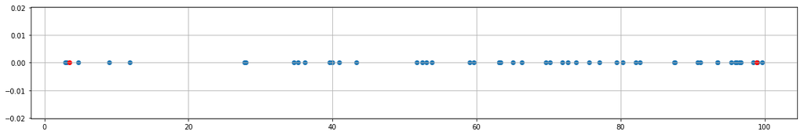

```python
plt.rcParams['figure.figsize'] = (20,3)
plt.grid(True)
plt.scatter(a, [0]*len(a))
p = 0.05
low, high = np.percentile(a, [100*p/2, 100*(1-p/2)])
print(low, high)
print(a[a<low])
print(a[a>high])
plt.scatter(np.percentile(a, [100*p/2, 100*(1-p/2)]), [0,0], c='r')
plt.show()
```

#### Получить индексы отсортированного массива

```python
m = np.random.randn(5)
print(m)
print(np.argsort(m))
for i in np.argsort(m):
    print(m[i], end=" ")
```

```
[-0.10352578  0.64331396 -0.44182246  0.87768801  0.15035183]
[2 0 4 1 3]
-0.44182246130953146 -0.10352577724621342 0.15035183427366702 0.6433139565872186 0.8776880109675866
```

Назад к Оглавлению

#### Умножение матрицы на вектор

```python
M = np.array([[1,2],[3,4]])
v = np.array([1,2])
np.dot(M, v)
```

```
array([ 5, 11])
```

#### Умножение матриц

```python
a = np.array([1,2,3,4]).reshape(2,2)
b = np.array([0,1,0,1]).reshape(2,2)
print("a={}".format(a))
print("b={}".format(b))
print(a*b)
print(a@b)
print(a.dot(b))
```

```
a=[[1 2]
 [3 4]]
b=[[0 1]
 [0 1]]
[[0 2]
 [0 4]]
[[0 3]
 [0 7]]
[[0 3]
 [0 7]]
```

#### Вычислить определитель матрицы

```python
A = np.array([1,2,3,4]).reshape(2,2)
print(A)
print(np.linalg.det(A))
```

```
[[1 2]
 [3 4]]
-2.0000000000000004
```

#### Найти обратную матрицу

```python
A = np.array([1,2,3,4]).reshape(2,2)
invA = np.linalg.inv(A)
print(A)
print(invA)
print(np.dot(A, invA))
print(np.dot(invA, A))
```

```
[[1 2]
 [3 4]]
[[-2.   1. ]
 [ 1.5 -0.5]]
[[1.00000000e+00 1.11022302e-16]
 [0.00000000e+00 1.00000000e+00]]
[[1.0000000e+00 4.4408921e-16]
 [0.0000000e+00 1.0000000e+00]]
```

#### Найти собственные значения матрицы

```python
A = np.array([1,1,1,1]).reshape(2,2)
print(A)
print(np.linalg.eigvals(A))
```

```
[[1 1]
 [1 1]]
[2. 0.]
```

#### Вычислить ранг матрицы (порядок наибольшего отличного от нуля минора)

```python
np.linalg.matrix_rank(np.ones(3))
```

```
1
```

Назад к Оглавлению

# Разные задачи

#### Использование функции np.choose

```python
np.choose?
```

```python
choices = [[1, 2, 3], [10, 20, 30], [100, 200, 300]]
np.choose([0, 1, 2], choices)
```

```
array([  1,  20, 300])
```

#### Использование функции np.argmax

```python
a = np.random.randint(low=1, high=10, size=(3, 4))
print(a)
```

```
[[6 8 1 2]
 [7 2 5 3]
 [4 8 8 5]]
```

```python
np.argmax(a), np.argmax(a, axis=0), np.argmax(a, axis=1)
```

```
(1, array([1, 0, 2, 2]), array([1, 0, 1]))
```

#### Использование функции np.squeeze

```python
m = [[1], [1,2,3,4]]
m1 = np.squeeze(m, axis=0)
print(m1)
```

```
[list([1]) list([1, 2, 3, 4])]
```

#### Сделать переход от декартовых координат к полярным

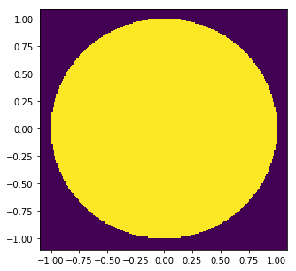

```python
xx, yy = np.meshgrid(np.arange(-1.1, 1.1, 0.01), np.arange(-1.1, 1.1, 0.01))
color = np.array([1 if x**2+y**2<1 else 0 for x,y in zip(xx.ravel(), yy.ravel())]).reshape(xx.shape)
plt.figure(figsize=(5,5))
plt.pcolormesh(xx, yy, color)
plt.show()
```

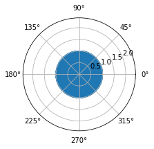

```python
rr = (xx.ravel())**2 + (yy.ravel())**2
ff = np.arctan2(xx.ravel(), yy.ravel())
plt.subplot(polar=True)
plt.scatter(ff, rr, color)
```

Назад к Оглавлению

# Настройки системы

#### Посмотреть текущую конфигурацию

```python
print(np.show_config())
```

```
blas_mkl_info:
  NOT AVAILABLE
blis_info:
  NOT AVAILABLE
openblas_info:
  NOT AVAILABLE
atlas_3_10_blas_threads_info:
  NOT AVAILABLE
atlas_3_10_blas_info:
  NOT AVAILABLE
atlas_blas_threads_info:
  NOT AVAILABLE
atlas_blas_info:
  NOT AVAILABLE
accelerate_info:
  NOT AVAILABLE
blas_info:
    libraries = ['blas', 'blas']
    library_dirs = ['/usr/lib/x86_64-linux-gnu']
    include_dirs = ['/usr/local/include', '/usr/include']
    language = c
    define_macros = [('HAVE_CBLAS', None)]
blas_opt_info:
    define_macros = [('NO_ATLAS_INFO', 1), ('HAVE_CBLAS', None)]
    libraries = ['blas', 'blas']
    library_dirs = ['/usr/lib/x86_64-linux-gnu']
    include_dirs = ['/usr/local/include', '/usr/include']
    language = c
lapack_mkl_info:
  NOT AVAILABLE
openblas_lapack_info:
  NOT AVAILABLE
openblas_clapack_info:
  NOT AVAILABLE
atlas_3_10_threads_info:
  NOT AVAILABLE
atlas_3_10_info:
  NOT AVAILABLE
atlas_threads_info:
  NOT AVAILABLE
atlas_info:
  NOT AVAILABLE
lapack_info:
    libraries = ['lapack', 'lapack']
    library_dirs = ['/usr/lib/x86_64-linux-gnu']
    language = f77
lapack_opt_info:
    define_macros = [('NO_ATLAS_INFO', 1), ('HAVE_CBLAS', None)]
    libraries = ['lapack', 'lapack', 'blas', 'blas']
    library_dirs = ['/usr/lib/x86_64-linux-gnu']
    language = c
    include_dirs = ['/usr/local/include', '/usr/include']
None
```

Назад к Оглавлению

# Ссылки

- https://numpy.org/ - официальная страница numpy
- https://github.com/rougier/numpy-100
- https://pythonworld.ru/numpy/100-exercises.html
- https://colab.research.google.com/ - интерактивная среда для программирования на python

Назад к Оглавлению